# Esports History

Anthony Cruz

10/27/2021

# Planning

Competitive video games, or esports, have been rising in worldwide popularity for decades. However, due to their relative novelty, there are no formal institutions responsible for tracking key metrics related to esport tournaments. This makes it difficult to find credible information on the evolution of esports relative to more traditional sports, such as baseball or football. The website https://www.esportsearnings.com/ attempts to remedy this problem by serving as a community-driven database for information on all sorts of esport tournaments, similar to a detailed Wikipedia page with data and references. This site may be not be comprehensive, but it contains details of tournaments as early as 1998 and should serve as a great source for tracking the evolution of esports over time. From user Ran.Kirsh on Kaggle (https://www.kaggle.com/rankirsh/esports-earnings), I have downloaded a web-scraped database of information available on this website.

## Story

I am going to tell the story of the state of esports and how it has changed over the years. The proportion of total esports earnings attributed to each game genre has changed dramatically across the years, with newer game styles seemingly overtaking older styles. However, regardless of genre, prize earnings, number of tournaments, and number of tournament participants all increased over the years prior to the COVID-19 pandemic. 2015 seems to be a significant year in terms of these variables, as after this year, there appear to be substantially more tournaments, more tournament participants, and more tournament earnings. Through assessing changes in genre representation, earnings, number of tournaments, and number of players, I will characterize the rising popularity of esports and some factors that may have affected it.

## Plots

First, I will create a pie chart to visualize how all-time esport tournament earnings are distributed by genre. Then, I will create a bar graph showing how this distribution has changed over time. My third plot will show raw totals of tournament earnings, number of tournaments, and number of tournament participants each year. My final plot will visualize the overall amount of players, tournaments, and earnings each year in one plot.

# Publication

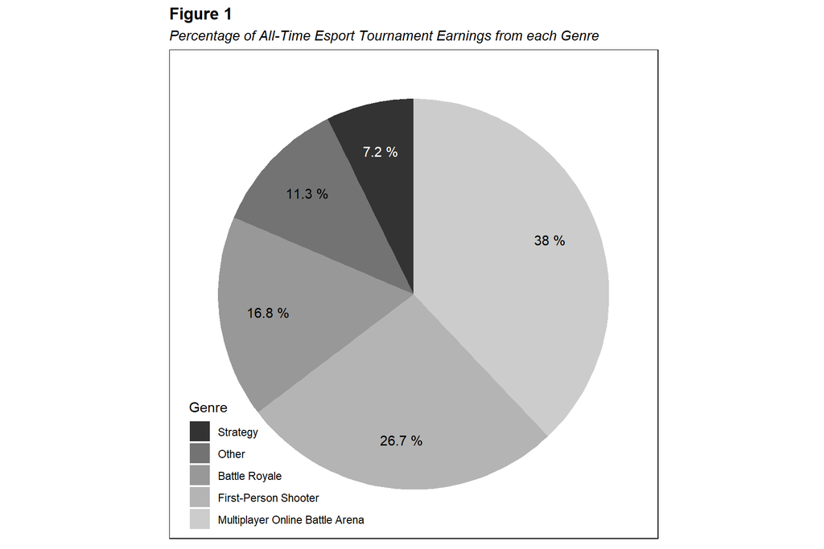

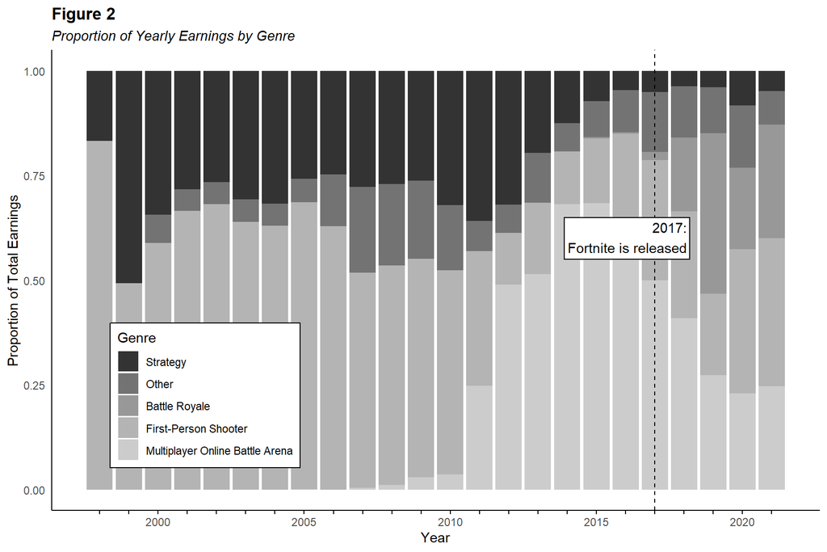

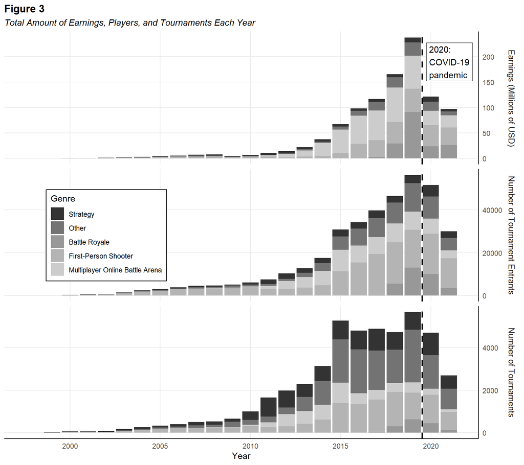

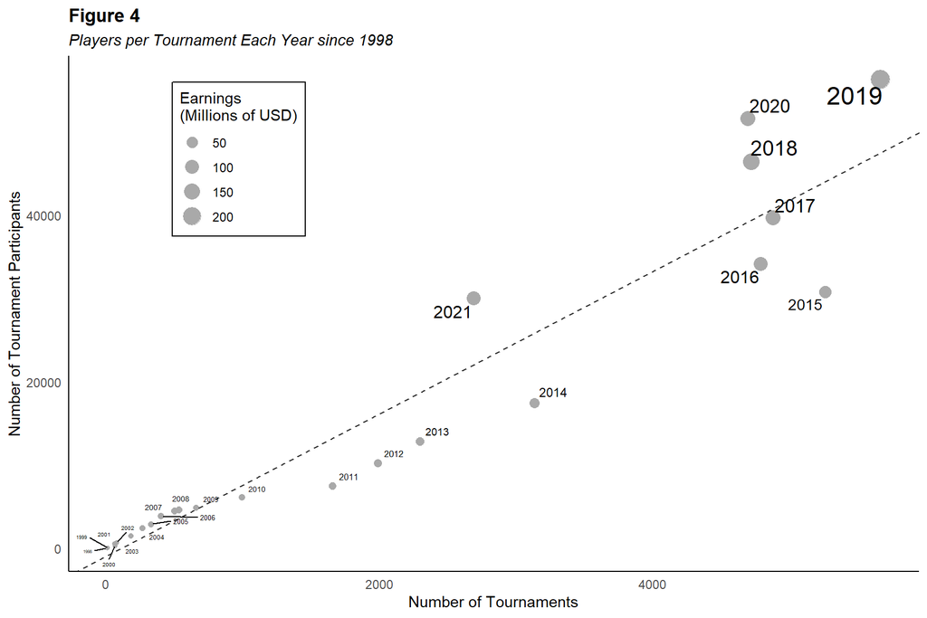

## Summary

**Figure 1** shows the proportion of all-time earnings attributed to each game genre. Genres representing less than 5% of all-time earnings (Collectible Card Game, Fighting Game, Puzzle Game, Racing, Role-Playing Game, Sports, Third-Person Shooter) will be collectively referred to as “Other” for the remainder of this analysis. **Figure 2** shows the proportion of total tournament earnings attributed to each genre in a given year. Interestingly, the Battle Royale genre seems to rise to prominence following the release of the popular Battle Royale game *Fortnite* in 2017. Despite its relative novelty, this genre now represents 16.8% of all-time earnings, ranking third overall.

**Figure 3** shows the raw amounts of tournament earnings, participants, and tournaments over the years. One clear observation is that COVID-19 severely impacted each of these metrics, showing a substantial decrease in 2020 following the peaks in 2019. Also of note is that the total number of tournaments seems to plateau while earnings and players continue to rise, suggesting that more players were entering tournaments and that tournaments began to have larger prizes.

## Justification

In each of these plots, I kept the color scale consistent, making it easy to tell apart genres from plot to plot. Since these plots are intended for publication, I kept the color scheme to a gray-scale, which is easy to read but is not distracting. Figure titles and subtitles follow APA guidelines. I included gridlines in **Figure 3** for clarity.

# Dynamic

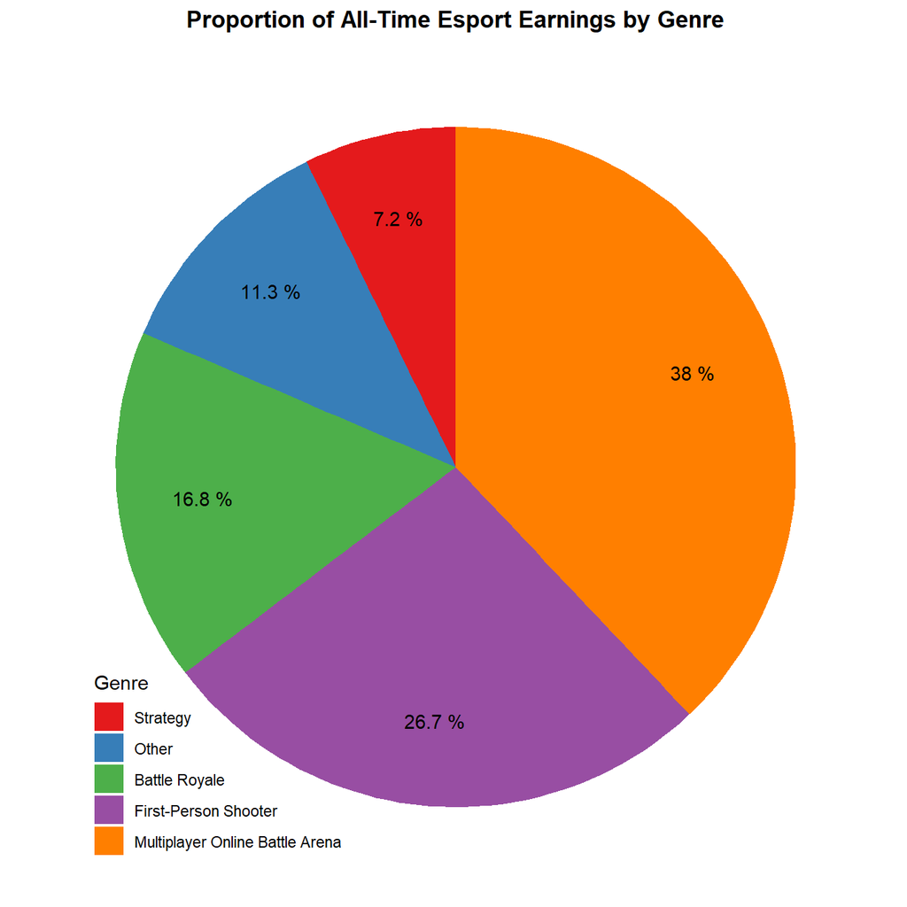

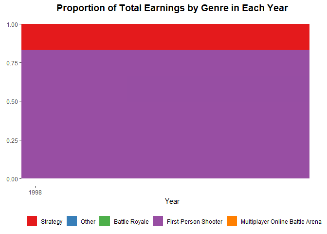

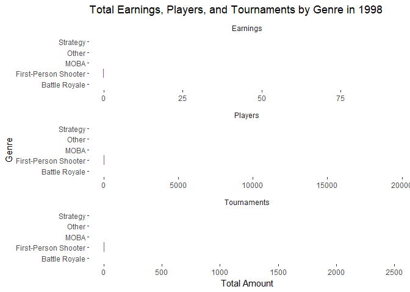

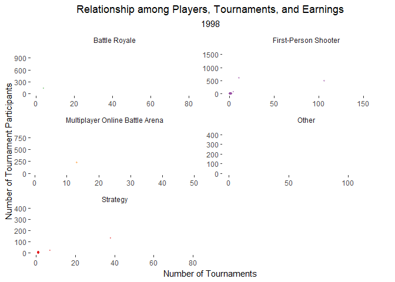

## Justification

For all of these plots, I used a color palette that makes differences between groups clearer. In the second plot, bars are touching, making it easy to follow color-to-color across the x-axis. In the third plot, unlike **Figure 3**, it is easy to compare among genres. The fourth plot provides more detailed information than **Figure 4**, showing the number of games involved in each genre rather than just raw totals.